# Redes Bayesianas

##### Johana Cómbita Niño

Introducción a la práctica

Utilizaremos un conjunto de datos diarios de ocurrencia de meteoros en el aeropuerto de Parayas (Santander), considerando una serie de variables meteorológicas registradas diariamente durante un periodo aproximado de 10 años (3286 registros), en concreto: precipitación, nieve, granizo, tormenta, niebla, rocío, escarcha, nieve en el suelo, neblina y racha máxima de viento superior a 50 km/h. Los datos se encuentran guardados en el fichero de texto meteoro.txt. Las variables se encuentran discretizadas de forma binaria (ocurrencia/ausencia).

En este caso, y a través del asesoramiento de un meteorólogo, se ha elaborado un diagrama acíclico dirigido (DAG), que recoge las relaciones de dependencia entre las variables.

```r
#Paquetes
library(bnlearn)
library(gRain)
library(ggplot2)
```

### Ejercicio 1

A partir del grafo dado por el experto, se determina la expresión que refleja la factorización de la distribución global. Se escribe como una secuencia de caracteres del tipo generado por la función modelstring del paquete de R bnlearn. Se crea el DAG utilizando la definicíon del modelo creado.

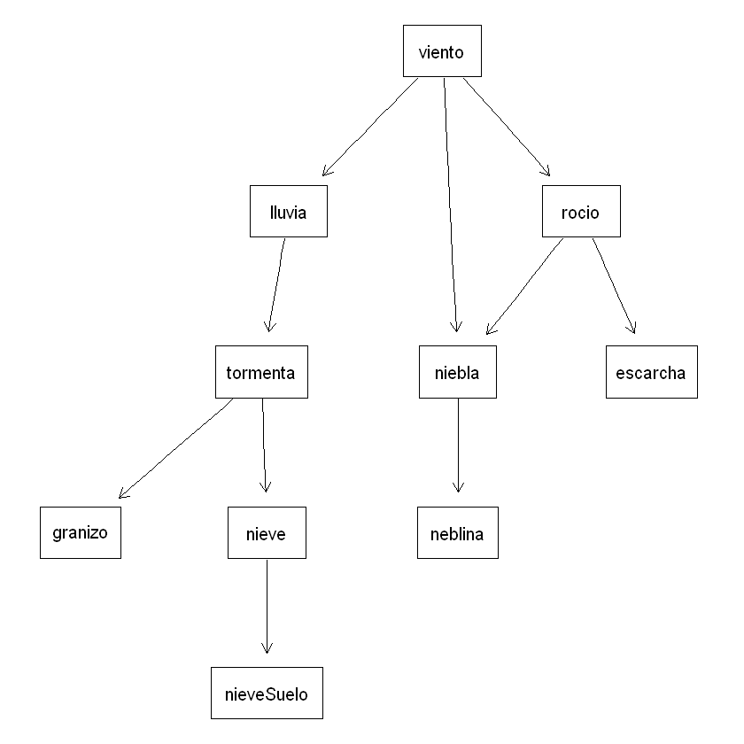

```r
# expresion model string
model_string = "[viento][lluvia|viento][tormenta|lluvia][granizo|tormenta][nieve|tormenta][nieveSuelo|nieve][niebla|viento:rocio][neblina|niebla][rocio|viento][escarcha|rocio]"

# definicion del dag
dag = model2network(model_string)

# graficar el dag
par(bg = "white")
graphviz.plot(dag)
```

Ahora se realiza una lista de los padres e hijos de cada uno de los nodos, para conocer las relaciones de la estructura (influencias).

```r
class(dag)
```

'bn'

```r
# lista de padres e hijos de cada nodo
dag_list = lapply(nodes(dag), function(node) {
  list(node = node,
       parents = bnlearn::parents(dag, node),
       children = bnlearn::children(dag, node))
})
```

Ahora se realiza una lista de todas las conexiones fundamentales presentes en el grafo, realizando una clasificación de cada una de ellas. Determinando si es una estructura en serie, divergente o convergente.

Partiendo del grafo anterior se identifican las siguientes conexiones fundamentales.

Estructuras en serie: Un nodo consecutivo al otro a manera de cascada.

- viento → lluvia → tormenta → granizo
- viento → lluvia → tormenta → nieve → nievesuelo
- viento → niebla → neblina
- viento → rocio → niebla → neblina
- viento → rocio → escarcha

A continuación, se representa una de estas estructuras en serie a manera de ejemplo:

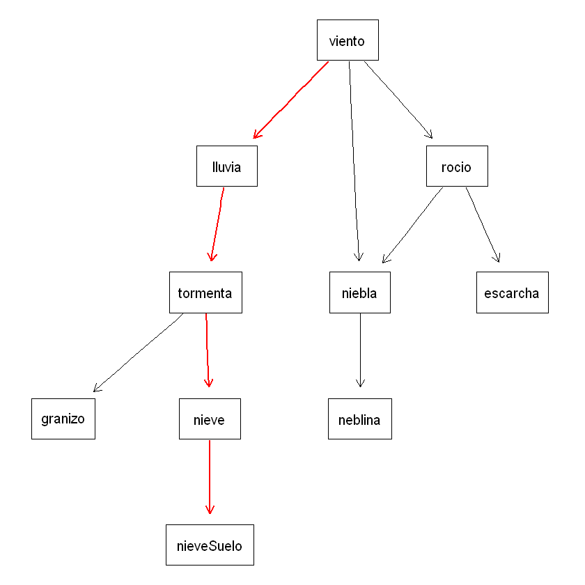

```r
# representación de estructura en serie más larga a manera de ejemplo
tripleta_arcos_s = matrix(c("viento","lluvia",
                           "lluvia","tormenta",
                            "tormenta","nieve",
                            "nieve","nieveSuelo"), ncol = 2, byrow = TRUE)

par(bg = "white")
graphviz.plot(dag, highlight = list(arcs = tripleta_arcos_s, col   = "red", lwd = 2))
```

Estructuras divergentes: nodos con padre en común. Tambien podría interpretarse como un nodo con varios hijos.

viento con hijos lluvia, niebla, rocio.

- lluvia ← viento → niebla
- lluvia ← viento → rocio
- niebla ← viento → rocio

tormenta con hijos granizo y nieve:

- granizo ← tormenta → nieve

rocio con hijos niebla y escarcha:

- niebla ← rocio → escarcha

A continuación, se representa una de estas estructuras divergentes a manera de ejemplo:

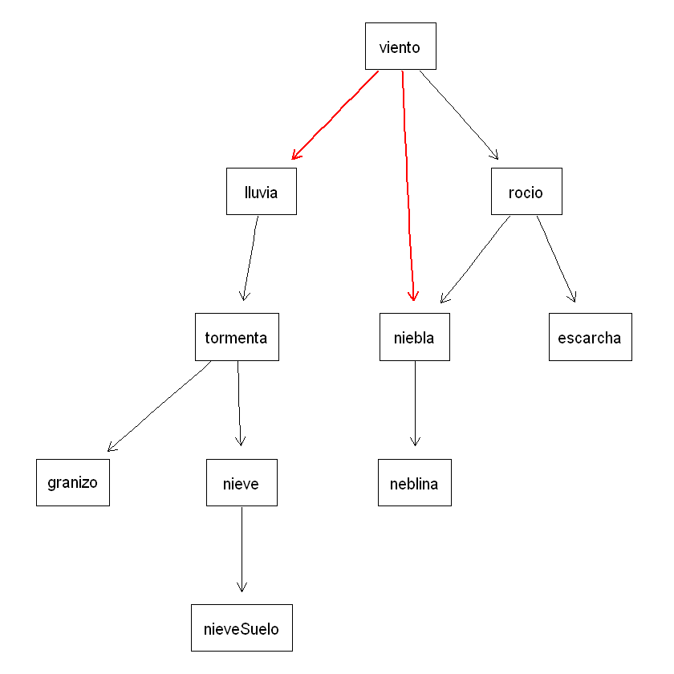

```r
# representación de estructura divergente
tripleta_arcos_d = matrix(c("viento","lluvia",
                            "viento", "niebla"), ncol = 2, byrow = TRUE)

par(bg = "white")
graphviz.plot(dag, highlight = list(arcs = tripleta_arcos_d, col   = "red", lwd = 2))
```

Estructuras convergentes: nodo que tiene varios padres.

- viento→niebla←rocio

A continuación, se hace la representación de esta estructura convergente.

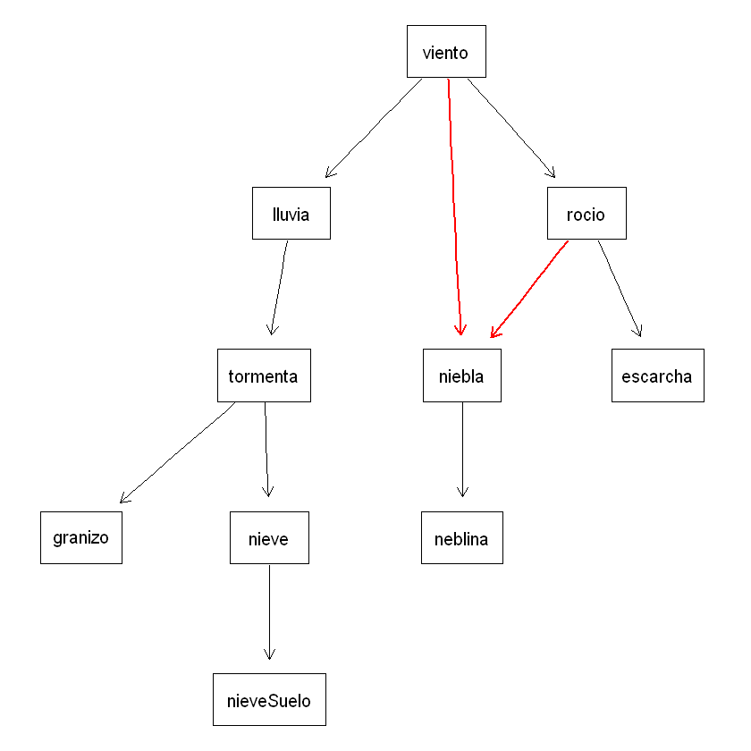

```r
# representación estructura convergente
tripleta_arcos_c = matrix(c("viento","niebla",
                            "rocio", "niebla"), ncol = 2, byrow = TRUE)

par(bg = "white")
graphviz.plot(dag, highlight = list(arcs = tripleta_arcos_c, col   = "red", lwd = 2))
```

¿Se observa alguna v-estructura en el grafo?

Es posible identificar v-estructuras con la función vstruct.

```r
vstructs(dag)
```

A matrix: 0 × 3 of type chr

| X | Z | Y |
| --- | --- | --- |

Se observa que no hay resultados, es decir que en el grafo no se identifican v-estructuras. Es importante mencionar que la relación convergente viento→niebla←rocio no se considera una v-estructura porque existe una relación entre viento y rocio, es decir, no son condicionalmente dependientes. Esto quiere decir que si no se da niebla los nodos viento y rocio son dependientes, si existe una relación.

A continuación, se introduce un arco que parta del nodo neblina y se dirija hacia escarcha, y otro que vaya de granizo a lluvia. Se comenta qué sucede en cada caso, y si el resultado da lugar a una red bayesiana válida.

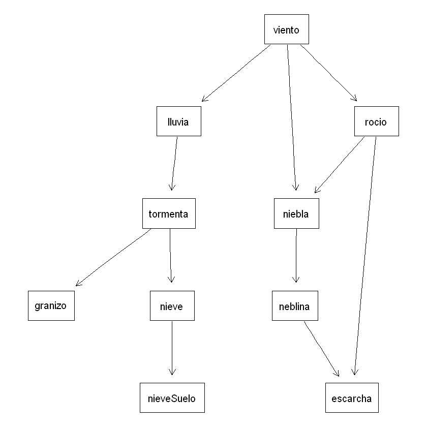

```r
# arco de neblina a escarcha
dag_n_e = set.arc(dag, "neblina", "escarcha")

# graficar el dag
par(bg = "white")
graphviz.plot(dag_n_e)
```

```r
vstructs(dag_n_e)
```

A matrix: 1 × 3 of type chr

| X | Z | Y |
| --- | --- | --- |
| neblina | escarcha | rocio |

Por su parte, se observa que no se forma un ciclo, por lo cual sigue siendo un DAG válido a nivel técnico, habría que validar si esta relación es coherente en términos meteorológicos.

En cuando al arco de granizo a lluvia:

```r
#arco de granizo a lluvia
dag_g_ll = set.arc(dag, "granizo", "lluvia")
# graficar el dag
par(bg = "white")
graphviz.plot(dag_g_ll)
```

[output not shown]

Se observa que no es posible generar un arco de granizo a lluvia debido a que se crearía un ciclo entre lluvia → tormenta → granizo → lluvia. Un grafo con ciclo deja de ser un DAG y, por tanto, no sería válido como red bayesiana. Recordemos que una red bayesiana se define sobre un grafo acíclico dirigido (DAG), lo cual implica que no puede haber ciclos dirigidos. Si existieran, no sería posible descomponer la distribución conjunta de todas las variables.

A continuación, se determina la manta de Markov del nodo rocio.

```r
bnlearn::mb(dag, "rocio")
```

1. 'escarcha'

2. 'niebla'

3. 'viento'

Recordemos que la manta de Markov de un nodo en una red bayesiana está compuesta por sus padres, hijos, y los otros padres de sus hijos. Para rocio, en el DAG original se observa que su padre es viento, sus hijos son niebla y escarcha, y otros padres sería viento (para el caso de niebla). Por tanto, la manta de Markov es escarcha, niebla y viento, como se muestra con la función mb.

Seguidamente, se introduce un arco que parta del nodo Lluvia y se dirija al nodo Niebla, ¿cambia la manta de Markov del nodo rocio? En caso afirmativo, ¿cómo lo hace?

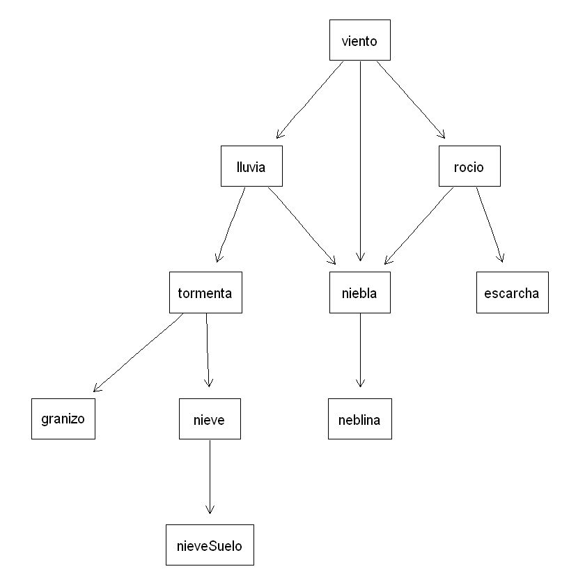

```r
# arco de lluvia a niebla
dag = set.arc(dag, "lluvia", "niebla")
# graficar el dag
par(bg = "white")
graphviz.plot(dag)
```

```r
bnlearn::mb(dag, "rocio")
```

1. 'escarcha'

2. 'lluvia'

3. 'niebla'

4. 'viento'

Con este arco se observa que cambia la manta de markov. Se observa que los padres e hijos de rocio se mantienen, pero los padres de sus hijos varían. Ahora niebla tiene 3 padres, donde lluvia es el nuevo padre con respecto a lo analizado anteriormente. Esto hace que ahora la manta de markov sea escarcha, niebla, viento y lluvia, como se observa en el resultado anterior.

A continuación, se elimina el arco definido anteriormente entre los nodos Lluvia y Niebla, recuperando el DAG original.

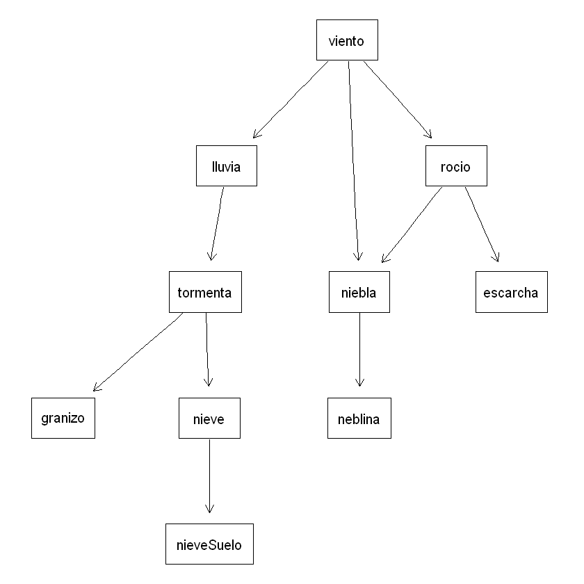

```r
dag = drop.arc(dag, "lluvia", "niebla")

# graficar el dag
par(bg = "white")
graphviz.plot(dag)
```

### Ejercicio 2

Considerando la información proporcionada por el conjunto de datos meteoro, se construye la red bayesiana utilizando el método bayesiano de estimación paramétrica.

Primero se cargan los datos:

```r
# carga de datos
meteoro = read.table("meteoro.txt", header = TRUE, stringsAsFactors = TRUE)
str(meteoro)
```

```
'data.frame':	3286 obs. of  10 variables:
 $ lluvia    : Factor w/ 2 levels "n","s": 2 2 2 2 2 2 2 2 2 1 ...
 $ nieve     : Factor w/ 2 levels "n","s": 1 1 1 1 1 1 1 1 1 1 ...
 $ granizo   : Factor w/ 2 levels "n","s": 1 1 1 1 2 2 1 1 1 1 ...
 $ tormenta  : Factor w/ 2 levels "n","s": 1 1 2 1 2 2 2 1 1 1 ...
 $ niebla    : Factor w/ 2 levels "n","s": 1 1 1 1 1 1 1 1 1 1 ...
 $ rocio     : Factor w/ 2 levels "n","s": 1 1 1 1 1 1 1 1 1 2 ...
 $ escarcha  : Factor w/ 2 levels "n","s": 1 1 1 1 1 1 1 1 1 1 ...
 $ nieveSuelo: Factor w/ 2 levels "n","s": 1 1 1 1 1 1 1 1 1 1 ...
 $ neblina   : Factor w/ 2 levels "n","s": 1 1 1 1 1 1 1 1 2 2 ...
 $ viento    : Factor w/ 2 levels "n","s": 2 2 2 2 2 2 2 2 1 1 ...
```

Luego se realiza el aprendizaje paramétrico con bn.fit con el método bayesian estimation (method = "bayes"), teniendo en cuenta que este utiliza tanto la información observada en los datos como la información previa de los parámetros.

```r
bn_model = bn.fit(dag, data = meteoro, method = "bayes")
```

¿Cuál sería el número potencial de parámetros (sin usar la red bayesiana) del modelo para calcular la probabilidad global si no utilizasemos el DAG?

Para un conjunto de n variables binarias, si no se usa ninguna factoración, es decir, se modela la distribución conjunta de forma plana, el número de parámetros necesarios para describir la probabilidad de cada combinación sería 2^n − 1. Esto quiere decir que hay 2^n celdas en la tabla completa y la suma de estas debe ser 1. Cómo en este ejercicio se tienen 10 variables, entonces:

```r
#parametros sin usar red bayesiana
(2^10) - 1
```

1023

¿Cuántos parámetros tiene la distribución global dada por la red bayesiana?

```r
# parametros de la red bayesiana
nparams(bn_model)
```

21

Los resultados muestran la reducción significativa de parámetros para el modelo, al usar una red bayesiana. Esto se debe a que la red bayesiana impone independencias condicionales, permitiendo descomponer la distribución conjunta en factores locales más pequeños; lo cual genera pasar de 1023 parámetros (para el caso de 10 variables binarias) a 21.

La clave de la reducción de parámetros está en que cada variable se modela solo con sus padres. Esto impone independencias condicionales que evitan que se tenga que estimar todas las combinaciones posibles de las demás variables.

Es importante mencionar que este permite un menor sobreajuste (menos parámetros), mayor interpretabilidad (mejor lectura de dependencias) y calculos eficientes (inferencias más manejables).

Ahora bien, el número de parámetros asociado a cada una de las distribuciones locales es:

```r
all_nodes = nodes(dag)

#conteo de padres
parents_count = sapply(all_nodes, function(n) {
  length(bnlearn::parents(dag, n))})

# Para un nodo binario con k padres, hay 2^k parámetros:
local_params = 2^parents_count

# dataframe con los resultados
df_params = data.frame( NumPadres = parents_count, ParametrosLocal = local_params)

df_params
```

A data.frame: 10 × 2

|  | NumPadres <int> | ParametrosLocal <dbl> |
| --- | --- | --- |
| escarcha | 1 | 2 |
| granizo | 1 | 2 |
| lluvia | 1 | 2 |
| neblina | 1 | 2 |
| niebla | 2 | 4 |
| nieve | 1 | 2 |
| nieveSuelo | 1 | 2 |
| rocio | 1 | 2 |
| tormenta | 1 | 2 |
| viento | 0 | 1 |

```r
#suma de los parámetros locales
sum(df_params$ParametrosLocal)
```

21

Para cada nodo binario dentro de la red, solo necesitamos un número de parámetros igual al número de combinaciones posibles de sus padres. Si un nodo tiene k padres, hay 2^k maneras distintas de asignarles valores, debido a que cada padre puede tomar dos valores, 0 o 1. Para cada una de esas combinaciones, se requiere un único parámetro que indique la probabilidad de que el nodo sea 1, y la probabilidad de que sea 0 se obtiene restando ese valor de 1. Por tanto, el total de parámetros de la red se calcula sumando para cada nodo la cantidad de combinaciones de sus padres.

Partiendo del modelo, se obtienen las tablas de probabilidad condicional asociadas a los nodos granizo y niebla. Se representa la información de cada tabla en sendos gráficos.

```r
bn_model$granizo
```

```
  Parameters of node granizo (multinomial distribution)

Conditional probability table:

       tormenta
granizo           n           s
      n 0.990183352 0.745742092
      s 0.009816648 0.254257908
```

Esta tabla nos muestra la probabilidad condicional de granizo, la cual se encuentra relacionada con tormenta, siendo el padre. De esta información es posible saber que cuando no hay tormenta la probabilidad de que no haya granizo es del 99%, siendo muy baja la probabilidad de que si haya granizo (0.9%). Además, indica que si hay tormenta la probabilidad de que no haya granizo es del 74%, y la probabilidad de que si haya es del 25%.

```r
bn_model$niebla
```

```
  Parameters of node niebla (multinomial distribution)

Conditional probability table:

, , viento = n

      rocio
niebla           n           s
     n 0.946399802 0.855234203
     s 0.053600198 0.144765797

, , viento = s

      rocio
niebla           n           s
     n 0.995195025 0.934108527
     s 0.004804975 0.065891473
```

Para el caso de niebla, se tienen dos padres, por lo cual se presenta la probabilidad conjunta para cada combinación. En términos generales, se observa que la mayor probabilidad dada la condición de que no haya viento y no haya rocio, es que la probabilidad de que no haya niebla es del 95% aproximadamente. Además, se observa que, dado que haya viento, pero no rocio, la probabilidad de que no haya niebla es del 99% aproximadamente.

De esta manera es posible hacer algunos análisis e interpretaciones.

A continuación, se representa la información de manera gráfica.

```r
#probabilidad de granizo
tab_granizo = bn_model$granizo$prob
tab_granizo
```

```
       tormenta
granizo           n           s
      n 0.990183352 0.745742092
      s 0.009816648 0.254257908
```

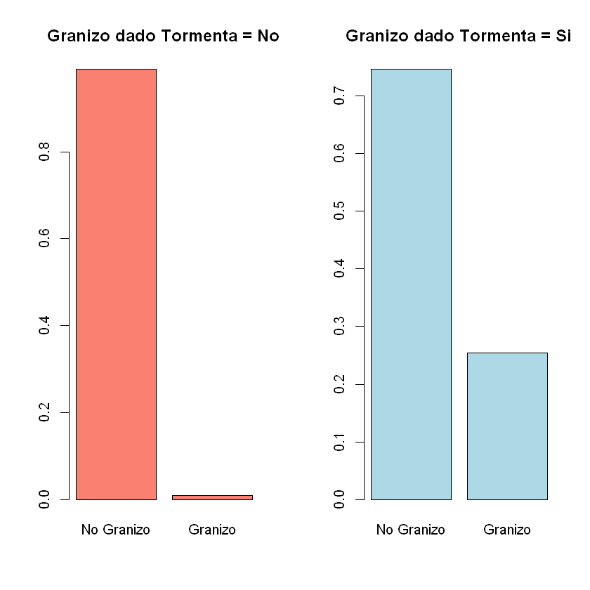

```r
# barplot por cada nivel de tormenta:
par(mfrow = c(1, 2), bg = "white")
barplot(tab_granizo[,1], names.arg = c("No Granizo", "Granizo"),
        main = "Granizo dado Tormenta = No", col = "salmon")

barplot(tab_granizo[,2], names.arg = c("No Granizo", "Granizo"),
        main = "Granizo dado Tormenta = Si", col = "lightblue")
```

A partir de este gráfico se observa que la probabilidad de que no haya granizo es alta en ambos escenarios, pero especialmente alta cuando no hay tormenta. Sin embargo, la probabilidad de que haya granizo aumenta significativamente cuando hay tormenta (pasa de 1% sin tormenta a 25% con tormenta). Por lo tanto, es más probable observar granizo si hay tormenta.

```r
#probabilidad de niebla
tab_niebla = bn_model$niebla$prob
tab_niebla
```

```
, , viento = n

      rocio
niebla           n           s
     n 0.946399802 0.855234203
     s 0.053600198 0.144765797

, , viento = s

      rocio
niebla           n           s
     n 0.995195025 0.934108527
     s 0.004804975 0.065891473
```

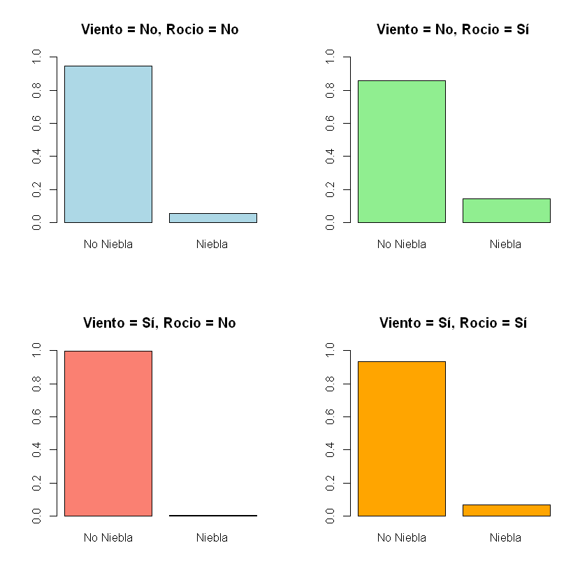

```r
# Representación gráfica para cada combinación de viento y rocio
par(mfrow = c(2, 2), bg = "white")

# viento = n, rocio = n
barplot(tab_niebla[, "n", "n"],
        names.arg = c("No Niebla", "Niebla"),
        main = "Viento = No, Rocio = No",
        col = "lightblue", ylim = c(0, 1))

# viento = n, rocio = s
barplot(tab_niebla[, "s", "n"],
        names.arg = c("No Niebla", "Niebla"),
        main = "Viento = No, Rocio = Sí",
        col = "lightgreen", ylim = c(0, 1))

# viento = s, rocio = n
barplot(tab_niebla[, "n", "s"],
        names.arg = c("No Niebla", "Niebla"),
        main = "Viento = Sí, Rocio = No",
        col = "salmon", ylim = c(0, 1))

# viento = s, rocio = s
barplot(tab_niebla[, "s", "s"],
        names.arg = c("No Niebla", "Niebla"),
        main = "Viento = Sí, Rocio = Sí",
        col = "orange", ylim = c(0, 1))
```

A partir de estos graficos es posible observar que en todos los escenarios condicionados por viento y rocio, la probabilidad de que no haya niebla es mayor. Sin embargo, se puede interpretar que la niebla es más probable cuando hay rocío y no hay viento (14%), y es menos probable cuando hay viento y no hay rocío (0.5%). Esto sugiere que la presencia de rocío, en ausencia de viento, incrementa la probabilidad de niebla.

### Ejercicio 3

Una vez construida la red hemos establecido la base de conocimiento del sistema inteligente. A continuación, se puede calcular la probabilidad de cualquier variable o conjunto de variables condicionadas a cualquier evidencia que se tenga disponible para un problema dado, es decir, realizar la inferencia.

Observa la estructura del DAG, repasa la teoría y el concepto de d-separación. Responde razonadamente si las siguientes afirmaciones son verdaderas o falsas, utilizando únicamente la estructura del DAG y el concepto de d-separación:

- La nieve y el granizo son fenómenos independientes a priori
- La nieve y el granizo son fenómenos independientes dado que haya habido tormenta
- La nieve en el suelo y la neblina son fenómenos independientes
- La nieve en el suelo y la neblina son fenómenos independientes dado que haya habido tormenta

Se verificar la independencia (o dependencia) entre variables usando el DAG y la función dsep() del paquete bnlearn en R. Esta función evalúa si dos variables están d-separadas, es decir, condicionalmente independientes en el grafo, dado un conjunto de nodos.

```r
#afirmación: La nieve y el granizo son fenómenos independientes a priori
dsep(dag, "nieve", "granizo")
```

FALSE

Al dar como resultado falso se evidencia que nieve y granizo no son independientes debido a que hay un camino entre estos nodos a través de tormenta. Esto quiere decir que la afirmación es Falsa.

```r
# Afirmación: La nieve y el granizo son fenómenos independientes dado que haya habido tormenta
dsep(dag, "nieve", "granizo", "tormenta")
```

TRUE

Al condicionar el nodo tomenta (nodo conexión) el camino se bloquea, dando como resultado una independencia dado tormenta (resultado True en dsep). Esto quiere decir que la afirmación es Verdadera.

```r
# Afirmación: La nieve en el suelo y la neblina son fenómenos independientes
dsep(dag, "nieveSuelo", "neblina")
```

FALSE

Aunque no hay una conexión directa, sí existe un camino a través de viento que está abierto mientras no se condicione. Esto quiere decir que nieveSuelo y neblina no son independientes, siendo Falsa la afirmación.

```r
# La nieve en el suelo y la neblina son fenómenos independientes dado que haya habido tormenta
dsep(dag, "nieveSuelo", "neblina", "tormenta")
```

TRUE

Tormenta conecta con granizo y nieve → nieveSuelo, pero neblina está en otro subgrafo independiente. El condicionar tormenta el camino se bloquea, dando como resultado una independencia (resultado TRue en dsep). Esto quiere decir que la afirmación es verdadera.

En este apartado se aplicará la inferencia exacta.

Si se conoce que en un determinado día se han producido tormentas, cómo afecta este hecho a la probabilidad de que se produzcan los siguientes fenómenos meteorológicos:

Primero se debe convertir el modelo a un objeto de tipo grain (implementado en la librería gRain) y usar la función compile, la cual genera el árbol de cliques, incluyendo el proceso de moralización, pero de manera inmediata. Con esto se tiene el árbol y las tablas de probabilidad calculada.

```r
bn_model_grain = compile(as.grain(bn_model))
```

A continuación, ya se pueden establecer las evidencias y hacer las consultas.

Primero se analiza cómo afecta este hecho a la probabilidad que se produzca lluvia.

```r
# Que llueva, P(lluvia=s|tormenta=s)
#probabilidad marginal de lluvia
marg_lluvia = querygrain(bn_model_grain, nodes = "lluvia")$lluvia["s"]
marg_lluvia

#evidencia
evidencia = setEvidence(bn_model_grain, nodes = "tormenta", state = "s")

#probabilidad condicional de lluvia dado tormenta
cond_lluvia = querygrain(evidencia, nodes = "lluvia")$lluvia["s"]
cond_lluvia
```

**s:** 0.555673866747794

**s:** 0.95985401459854

La probabilidad de que llueva es del 55% aproximadamente, pero esta probabilidad aumenta dado exista una tormenta hasta el 95%. Indicando prácticamente que si hay tormenta hay lluvia.

Esto responde a la pregunta de que si hay mayor probabilidad de que llueva cuando se producen tormentas, que cualquier otro día.

Luego, como afecta a la probabilidad de rachas de viento.

```r
# Que haya rachas de viento superiores a 50 Km/h, P(viento=s|tormenta=s)

#probabilidad marginal de viento
marg_viento = querygrain(bn_model_grain, nodes = "viento")$viento["s"]
marg_viento

#probabilidad condicional de viento dado tormenta
cond_viento = querygrain(evidencia, nodes = "viento")$viento["s"]
cond_viento
```

**s:** 0.14435655613021

**s:** 0.216860789374449

La probabilidad marginal de que haya rachas de viento es del 14% aproximadamente, pero esta aumenta a un 21% bajo la condición de que haya tormenta.

Esto responde a la pregunta de que aumenta la probabilidad de tener rachas de viento mayores de 50 Km/h cuando se produce una tormenta. Adicionalmente, se interpreta que, como la probabilidad pasó de 0.14 a 0.21, se tiene un incremento absoluto de 0.07 (7 puntos porcentuales), equivalente a un aumento relativo del 50% respecto a la probabilidad original.

```r
(0.21 - 0.14) / 0.14
```

0.5

Finalmente, cómo afecta a la probabilidad conjunta de lluvia y viento.

```r
# Que llueva y que además las rachas de viento superen los 50 Km/h, P(lluvia=s,viento=s|tormenta=s)

#probabilidad conjunta marginal de lluvia y viento
marg_lluvia_viento = querygrain(bn_model_grain, nodes = c("lluvia", "viento"), type = "joint")["s", "s"]
marg_lluvia_viento

#probabilidad conjunta condicional de lluvia y viento dado tormenta
cond_lluvia_viento = querygrain(evidencia, nodes = c("lluvia", "viento"), type = "joint")["s", "s"]
cond_lluvia_viento
```

0.124505628232431

0.215067208034192

La probabilidad conjunta de que llueva y haya rachas de viento es de 12.4%. La probabilidad condicional dado haya tormenta hace que aumente la probabilidad de lluvia y viento a 21.5%. Esto indica que la tormenta aumenta la probabilidad conjunta de este escenario.

Dado el ejercicio anterior, se repite ahora el ejercicio mediante inferencia aproximada, calculando para cada una de las estimaciones 100 realizaciones. Para cada una de las respuestas anteriores, se representa un diagrama de cajas que muestre la dispersión en la estimación de la probabilidad, marcando el valor obtenido de manera exacta en el apartado anterior.

Primero se calculan las probabilidades estimadas para 100 realizaciones (bucle N=100), en cada uno de los escenarios anteriores. Es importante mencionar que se utiliza el método "lw" debido a que se basa en generar observaciones aleatorias de tal modo que todas ellas coinciden con la evidencia dada, asignando pesos a cada una de ellas para calcular las probabilidades condicionales al realizar la consulta. Además, se utiliza el valor por defecto n=5000 (número de observaciones aleatorias).

```r
# P(lluvia=s|tormenta=s)
N = 100
result_P1 = rep(NA, N)

set.seed(304)
for (i in 1:N) {
    prob_est = cpquery(bn_model, event = (lluvia == "s"), evidence = list(tormenta = "s"), method = "lw")
    result_P1[i] = prob_est
}
```

```r
# P(viento = "s" | tormenta = "s")
result_P2 = rep(NA, N)

set.seed(304)
for (i in 1:N) {
    prob_est = cpquery(bn_model, event = (viento == "s"), evidence = list(tormenta = "s"), method = "lw")
    result_P2[i] = prob_est
}
```

```r
# P(lluvia = "s", viento = "s" | tormenta = "s")
result_P3 = rep(NA, N)

set.seed(304)
for (i in 1:N) {
    prob_est = cpquery(bn_model, event = (lluvia == "s") & (viento == "s"), evidence = list(tormenta = "s"), method = "lw")
    result_P3[i] = prob_est
}
```

Se compara la inferencia aproximada con la inferencia exacta (punto anterior), teniendo en cuenta las 100 realizaciones. Esta comparación se hace a través de un diagrama de cajas para representar la dispersión en la estimación de la probabilidad por parte de la inferencia aproximada. Además, se marca el resultado de la inferencia exacta para ver si el valor es cercano.

```r
# preparación de los resultados
df = data.frame(
  valor = c(result_P1, result_P2, result_P3),
  tipo = factor(rep(c("Lluvia | Tormenta", "Viento | Tormenta", "Lluvia & Viento | Tormenta"), each = N))
)
```

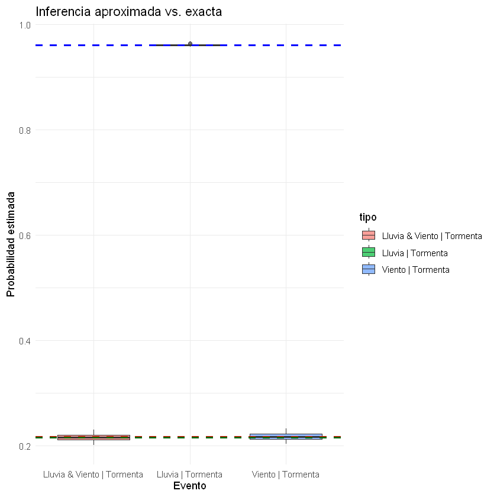

```r
#grafico conjunto
ggplot(df, aes(x = tipo, y = valor, fill = tipo)) +
  geom_boxplot(alpha = 0.7) +
  geom_hline(yintercept = cond_lluvia, color = "blue", linetype = "dashed", linewidth = 1, show.legend = FALSE) +
  geom_hline(yintercept = cond_viento, color = "red", linetype = "dashed", linewidth = 1, show.legend = FALSE) +
  geom_hline(yintercept = cond_lluvia_viento, color = "darkgreen", linetype = "dashed", linewidth = 1, show.legend = FALSE) +
  labs(title = "Inferencia aproximada vs. exacta",
       x = "Evento",
       y = "Probabilidad estimada") +
  theme_minimal()
```

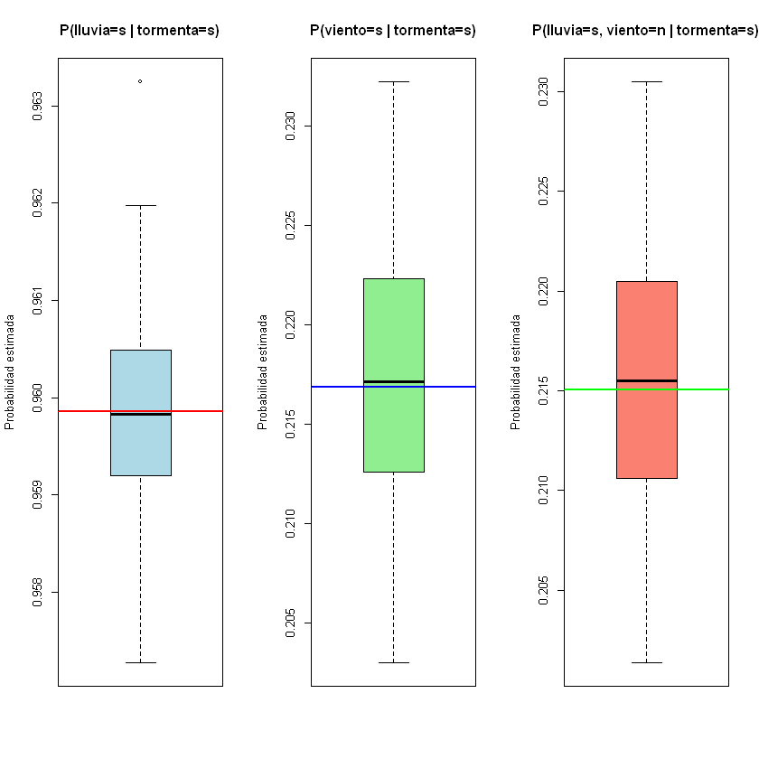

```r
#grafico por separado
par(mfrow = c(1, 3), bg = "white")
boxplot(result_P1,
        main = "P(lluvia=s | tormenta=s)",
        ylab = "Probabilidad estimada",
        col = "lightblue")
abline(h = cond_lluvia, col = "red", lwd = 2)

boxplot(result_P2,
        main = "P(viento=s | tormenta=s)",
        ylab = "Probabilidad estimada",
        col = "lightgreen")
abline(h = cond_viento, col = "blue", lwd = 2)

boxplot(result_P3,
        main = "P(lluvia=s, viento=n | tormenta=s)",
        ylab = "Probabilidad estimada",
        col = "salmon")
abline(h = cond_lluvia_viento, col = "green", lwd = 2)
```

A partir de los gráficos se observa que en 100 repeticiones de cpquery las probabilidades aproximadas se concentran alrededor del valor de inferencia exacta. Es posible observar la variabilidad a través del gráfico dada la amplitud de la caja, la cual no es significativamente variables, es decir que los valores de probabilidad aproximada son muy cercanos a la exacta. Además, se observa que la mediana de las probabilidades aproximadas es muy cercana al valor exacto.

En la última gráfica se observa que se aleja un poco en el escenario P(lluvia=s, viento=s | tormenta=s), pero no es significativa la diferencia. Es importante mencionar que estos resultados favorables se deben al método lw, el n (samples por defecto 5000 en cpquery) y el número de realizaciones. Entre más alto sea n y más realizaciones se hagan, mejor serán los resultados; sin embargo, se debe tener en cuenta el coste computacional.

### Ejercicio 4

Como hemos visto, es posible realizar un aprendizaje automático de la estructura del DAG a partir de los datos, usando algoritmos específicos para ello. Durante las clases hemos visto el ejemplo del algoritmo hill-climbing, aunque como vimos, hay otras posibilidades. Tambien hemos visto que podemos combinar nuestra experiencia y el aprendizaje automático definiendo previamente relaciones entre variables que queremos introducir o descartar en el DAG resultante. Además, se ha explicado que existen scores que sirven como criterio para evaluar la fuerza de la dependendencia entre nodos de la red y comparar la bondad de ajuste del modelo.

A continuación, se evalúa la significación de los arcos dibujados por el experto en el actual DAG utilizando el estadístico χ2. ¿Hay algún arco no significativo? ¿Cuáles son los tres pares de nodos que presentan un arco de unión más fuerte?

```r
#fuerza de los arcos con test x^2
fuerza = arc.strength(dag, meteoro, criterion = "x2")
fuerza
```

A bn.strength: 10 × 3

|  | from <chr> | to <chr> | strength <dbl> |
| --- | --- | --- | --- |
| 1 | viento | lluvia | 5.887107e-48 |
| 2 | lluvia | tormenta | 1.707081e-33 |
| 3 | tormenta | granizo | 3.189229e-104 |
| 4 | tormenta | nieve | 1.051550e-13 |
| 5 | nieve | nieveSuelo | 2.515328e-101 |
| 6 | viento | niebla | 1.591451e-05 |
| 7 | rocio | niebla | 2.087399e-17 |
| 8 | niebla | neblina | 1.300969e-27 |
| 9 | viento | rocio | 1.730098e-23 |
| 10 | rocio | escarcha | 2.106559e-05 |

```r
# arcos con fuerza no significativa
subset(fuerza, strength > 0.05)
```

A bn.strength: 0 × 3

| from | to | strength |
| --- | --- | --- |
| <chr> | <chr> | <dbl> |

```r
# arcos con mayor fuerza significativa
top3 = fuerza[order(fuerza$strength), ][1:3, ]
top3
```

A bn.strength: 3 × 3

|  | from <chr> | to <chr> | strength <dbl> |
| --- | --- | --- | --- |
| 3 | tormenta | granizo | 3.189229e-104 |
| 5 | nieve | nieveSuelo | 2.515328e-101 |
| 1 | viento | lluvia | 5.887107e-48 |

Este test evalúa la probabilidad de que el arco sea realmente necesario, midiendo la fuerza de dependencia probabilística de cada arco. Para esto, se evalúa que los p-valor de cada arco sean menor a 0.05, indicando que las relaciones de dependencia expresadas por dichos arcos están bien sustentadas por los datos. De acuerdo con los resultados, se observa que todos los arcos son significativos debido a que cumplen la anterior condición. Además, se puede interpretar que los tres pares de nodos que representan los arcos de unión más fuerte son {tormenta , granizo}, {nieve, nieveSuelo} y {viento, lluvia}.

Además del algoritmo hill-climbing, existe otro algoritmo popular de tipo “voraz” denominado Tabu search. En bnlearn se encuentra implementado a traves de la función tabu, y los argumentos de entrada son similares a los vistos para hill-climbing.

Se compara el score global (BIC) obtenido por el DAG inicial, con los obtenidos por los DAG aprendidos de forma automática con los algoritmos tabu y hill-climbing. ¿Cuál obtiene mejor score?

Primero se aprenden dos nuevos DAGs con los algoritmos de tabu y hill-climbing, indicando el score BIC.

```r
# DAG con Hill-Climbing
dag_hc = hc(meteoro, score = "bic")

# DAG con Tabu Search
dag_tabu = tabu(meteoro, score = "bic")
```

Luego se calculan y se comparan los scores BIC para los tres DAGs.

```r
# score del modelo del experto
bnlearn::score(dag, meteoro, type = "bic")
# score del modelo de Hill-Climbing
bnlearn::score(dag_hc, meteoro, type = "bic")
# score del modelo de Tabu Search
bnlearn::score(dag_tabu, meteoro, type = "bic")
```

-9724.87249672025

-9366.74970604666

-9365.17454049124

El BIC se trata de un estadístico que mide la bondad de ajuste del DAG a la estructura de dependencias implícita en los datos. En el contexto de redes bayesianas, se utiliza como criterio para comparar diferentes estructuras de grafos, y escoger la mejor estructura que se ajusta a los datos.

A menor penalización, es decir a mayor valor del BIC, mejor es el modelo según este criterio. En este sentido, el modelo obtenido por tabu search alcanza el mejor BIC; sin embargo, la diferencia con el modelo aprendido mediante hill-climbing es pequeña (aproximadamente 1.58 puntos), lo que sugiere que ambos modelos presentan un ajuste similar a los datos.

Ahora, para comparar el DAG original con los dos nuevos DAG tabu y hill-climbing, se dibuja los tres utilizando la función graphviz.plot. A la luz de los grafos obtenidos en cada caso, ¿cuál te parece que recoge mejor las relaciones causa-efecto entre variables?. (Hay que tener en cuenta que los arcos de un grafo no expresan causalidad, sino simplemente dependencia entre variables en términos de probabilidad)

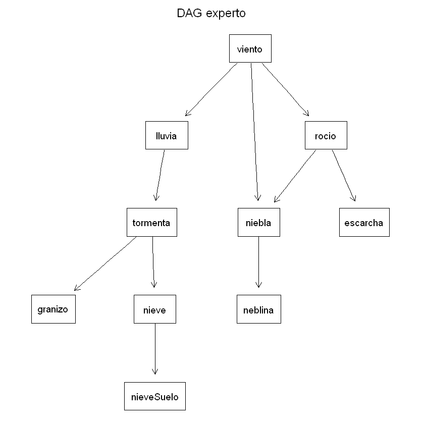

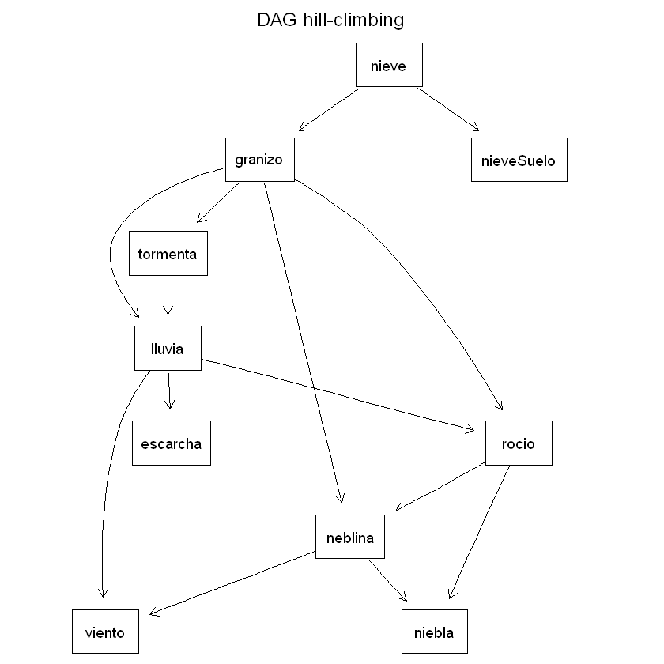

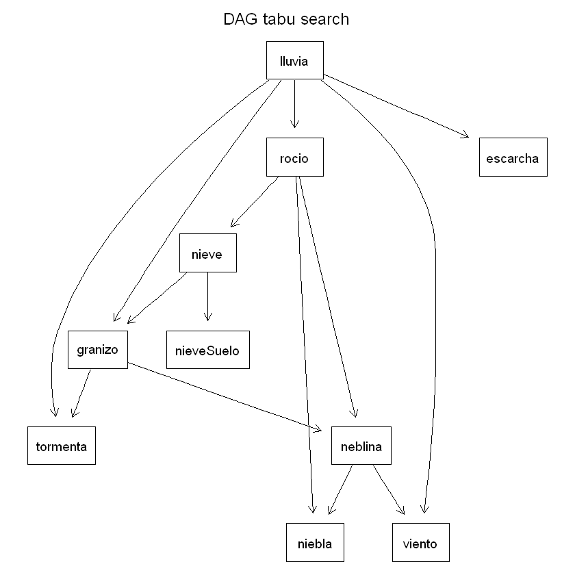

```r
par( bg = "white")

# DAG original del experto
graphviz.plot(dag, main = "DAG experto")
# DAG aprendido con Hill-Climbing
graphviz.plot(dag_hc, main = "DAG hill-climbing")
# DAG aprendido con Tabu Search
graphviz.plot(dag_tabu, main = "DAG tabu search")
```

Al comparar los tres DAGs (experto, hill-climbing y tabu search), se evidencian diferencias relevantes tanto en la estructura como en las relaciones entre variables. En primer lugar, se observa que el nodo raíz (aquel que es padre pero no hijo) cambia según el modelo: en el DAG del experto es viento, en el de hill-climbing es nieve y en el de tabu search es lluvia.

En segundo lugar, se observa que algunas relaciones cambian de dirección, formando conexiones fundamentales diferentes, por ejemplo, en el caso de experto se tenía una conexión en serie viento → niebla → neblina, y para Tabu y HC cambia a una conexión divergente niebla ← neblina → viento. Otro ejemplo es, en sistema de experto se tiene una conexión en serie lluvia → tormenta → granizo, en HC y Tabu se genera conexión convergente (cambiando el sentido de las flechas) granizo → lluvia ← tormenta, y lluvia → tormenta ← granizo, respectivamente.

Como estos, hay más ejemplos que muestra los cambios significativos con respecto al grafo generado con el sistema de expertos; sin embargo, se resalta que se mantienen algunas relaciones coherentes como nieve → nieve suelo (en las tres), lluvia → tormenta (en Tabu en esta dirección y en HC inverso), rocio → niebla (en las tres).

Finalmente, es importante analizar algunas relaciones meteorológicas para ver la coherencia en los modelos de HC y Tabu. Por ejemplo, en el sistema de expertos se tiene que nieve y granizo son fenómenos independientes dado tormenta, lo cual es coherente debido a que una tormenta puede traer nieve o granizo, pero este tipo de relación cambia en Tabu y HC, siendo una conexión en serie e implicando una dependencia directa. Adicionalmente, se observan relaciones diferentes como lluvia → escarcha (HC y Tabu) cuando en el sistema de experto no existe y no es coherente pensar una probabilidad de escarcha dado lluvia. También sucede esto con la relación rocio → nieve (Tabu), donde en el sistema de experto no existía esta relación y no tiene coherencia una probabilidad de nieve dado rocio. Un último ejemplo es la relación granizo → neblina (HC), donde no existe en el sistema de experto y tampoco es del todo coherente.

En este sentido, es importante mencionar que los algoritmos buscan optimizar el score (BIC en este caso) para generar el mejor modelo que ajusta a los datos; sin embargo, pueden suceder este tipo de aspectos analizados anteriormente, donde se presenten estructuras que no son coherentes frente al sistema de expertos. En este sentido, desde mi punto de vista ninguno de los grafos generados con el algoritmo son del todo coherentes para considerarlo en vez del sistema de experto, pese a que se obtuvo un mejor score o ajuste estadístico. Entonces, la mejor relación causa-efecto entre variables seria la del sistema de experto.

A continuación, se vuelve a aprender de forma automática el DAG usando tabu y hill-climbing, pero imponiendo las siguientes restricciones:

1. Los arcos viento --> lluvia, tormenta --> granizo y nieve --> nieveSuelo deben quedar reflejados en el DAG.
2. Ningún arco debe unir directamente la neblina con el granizo ni la niebla con la tormenta.

De esta manera, se puede obtener un mejor modelo que considera aspectos importantes que se quieren rescatar del sistema de experto y relaciones que no deberían existir para garantizar la coherencia.

Primero se definen las relaciones obligatorias y prohibidas (whitelist, blacklist)

```r
# whitelist
wl = matrix(c("viento", "lluvia",
            "tormenta", "granizo",
            "nieve", "nieveSuelo"), ncol = 2, dimnames = list(NULL, c("from", "to")), byrow = TRUE)
wl

# blacklist
bl = matrix(c("neblina", "granizo",
            "granizo", "neblina",
            "niebla", "tormenta",
            "tormenta", "niebla"), ncol = 2, dimnames = list(NULL, c("from", "to")), byrow = TRUE)
bl
```

A matrix: 3 × 2 of type chr

| from | to |
| --- | --- |
| viento | lluvia |
| tormenta | granizo |
| nieve | nieveSuelo |

A matrix: 4 × 2 of type chr

| from | to |
| --- | --- |
| neblina | granizo |
| granizo | neblina |
| niebla | tormenta |
| tormenta | niebla |

Luego se aprenden los nuevos DAGs con estas restricciones.

```r
# Hill-Climbing con whitelist y blacklist
dag_hc_wl_bl = hc(meteoro, score = "bic", whitelist = wl, blacklist = bl)

# Tabu Search con whitelist y blacklist
dag_tabu_wl_bl = tabu(meteoro, score = "bic", whitelist = wl, blacklist = bl)
```

Se vuelve a dibujar los DAG resultantes.

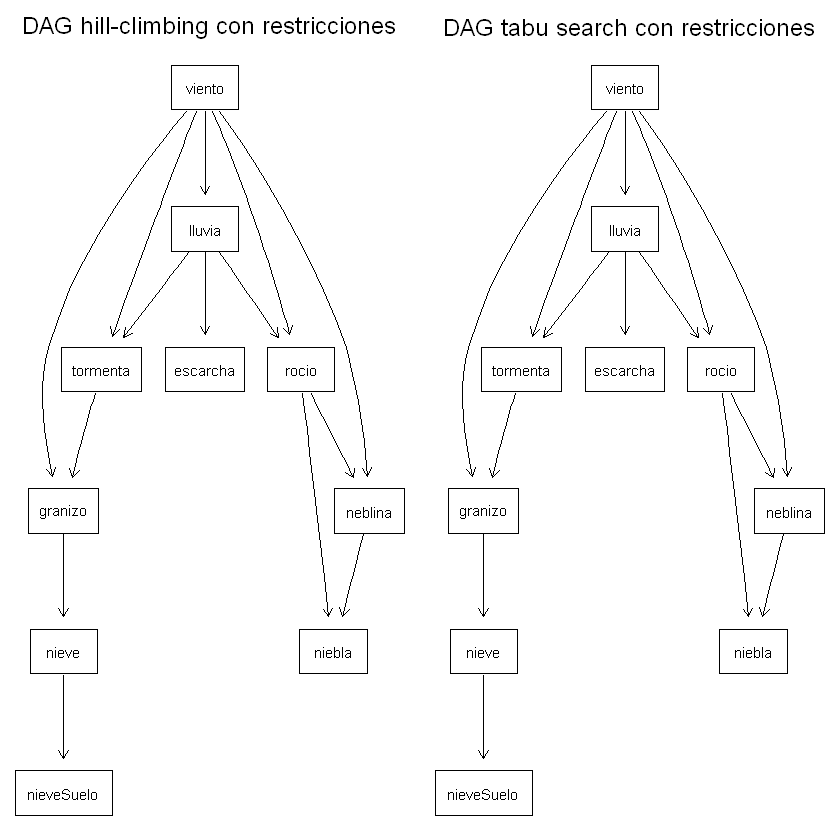

```r
#DAGs aprendidos con whitelist y blacklist
par(mfrow = c(1, 2), bg = "white")
graphviz.plot(dag_hc_wl_bl, main = "DAG hill-climbing con restricciones")
graphviz.plot(dag_tabu_wl_bl, main = "DAG tabu search con restricciones")
```

Tras imponer las restricciones propuestas (arcos obligatorios y prohibidos), tanto el algoritmo hill-climbing como tabu search convergieron a la misma estructura. Estos resultados son coherentes debido a que las restricciones reducen considerablemente el espacio de búsqueda posible, guiando ambos algoritmos hacia la misma solución óptima dentro del conjunto de DAGs válidos.

Es importante mencionar que se presentan relaciones muy similares a las establecidas por el sistema de experto, garantizando la coherencia con respecto a ciertas relaciones meteorológicas, manteniendo las relaciones claves y evitando las relaciones problemáticas. Con esto, se podría interpretar que las restricciones son suficientemente relevantes, que hace que ambos modelos converjan a la misma solución a pesar de usar estrategias diferentes.

A partir del BIC obtenido por cada modelo, se determina cuál es el mejor de todos, poniéndolos en una tabla.

```r
bic_tabla = data.frame(
  Modelo = c("Experto", "HC libre", "Tabu libre", "HC con restricciones", "Tabu con restricciones"),
  BIC = c(
    bnlearn::score(dag, meteoro, type = "bic"),
    bnlearn::score(dag_hc, meteoro, type = "bic"),
    bnlearn::score(dag_tabu, meteoro, type = "bic"),
    bnlearn::score(dag_hc_wl_bl, meteoro, type = "bic"),
    bnlearn::score(dag_tabu_wl_bl, meteoro, type = "bic")
  )
)

bic_tabla[order(-bic_tabla$BIC), ]
```

A data.frame: 5 × 2

|  | Modelo <chr> | BIC <dbl> |
| --- | --- | --- |
| 4 | HC con restricciones | -9361.871 |
| 5 | Tabu con restricciones | -9361.871 |
| 3 | Tabu libre | -9365.175 |
| 2 | HC libre | -9366.750 |
| 1 | Experto | -9724.872 |

Los resultados obtenidos muestran que, al aplicar los algoritmos de hill-climbing y tabu search junto con restricciones derivadas del conocimiento experto, se alcanza el mejor valor del BIC (−9361.87), lo cual indica un ajuste estadístico superior en comparación con el resto de los modelos evaluados.

Además, al igual que en la estructura de los grafos, ambos algoritmos coinciden en el valor del BIC, lo que sugiere que las restricciones impuestas guiaron de forma efectiva el aprendizaje hacia una solución óptima común. Por tanto, ambos modelos pueden considerarse como opciones altamente adecuadas para representar las dependencias probabilísticas del sistema.

Finalmente, se computa la fuerza de la relación entre nodos de los dos últimos modelos que combinan la experiencia con el aprendizaje automático.

```r
strength_hc = arc.strength(dag_hc_wl_bl, data = meteoro, criterion = "x2")
strength_tabu = arc.strength(dag_tabu_wl_bl, data = meteoro, criterion = "x2")

# fuerza no significativa
subset(strength_hc, strength > 0.05)
subset(strength_tabu, strength > 0.05)
```

A bn.strength: 0 × 3

| from | to | strength |
| --- | --- | --- |
| <chr> | <chr> | <dbl> |

A bn.strength: 0 × 3

| from | to | strength |
| --- | --- | --- |
| <chr> | <chr> | <dbl> |

```r
# ordenado por fuerza
strength_hc[order(strength_hc$strength), ]
strength_tabu[order(strength_tabu$strength), ]
```

A bn.strength: 14 × 3

|  | from <chr> | to <chr> | strength <dbl> |
| --- | --- | --- | --- |
| 3 | nieve | nieveSuelo | 2.515328e-101 |
| 4 | lluvia | rocio | 1.588620e-78 |
| 2 | tormenta | granizo | 1.375034e-67 |
| 1 | viento | lluvia | 5.887107e-48 |
| 5 | rocio | neblina | 9.575702e-44 |
| 8 | viento | neblina | 1.401866e-29 |
| 11 | granizo | nieve | 1.243591e-28 |
| 6 | lluvia | tormenta | 9.350705e-27 |
| 7 | neblina | niebla | 8.140958e-19 |
| 9 | lluvia | escarcha | 8.743909e-12 |
| 12 | rocio | niebla | 4.868168e-09 |
| 10 | viento | rocio | 1.009701e-08 |
| 13 | viento | granizo | 3.039235e-08 |
| 14 | viento | tormenta | 1.624833e-06 |

A bn.strength: 14 × 3

|  | from <chr> | to <chr> | strength <dbl> |
| --- | --- | --- | --- |
| 3 | nieve | nieveSuelo | 2.515328e-101 |
| 4 | lluvia | rocio | 1.588620e-78 |
| 2 | tormenta | granizo | 1.375034e-67 |
| 1 | viento | lluvia | 5.887107e-48 |
| 5 | rocio | neblina | 9.575702e-44 |
| 8 | viento | neblina | 1.401866e-29 |
| 11 | granizo | nieve | 1.243591e-28 |
| 6 | lluvia | tormenta | 9.350705e-27 |
| 7 | neblina | niebla | 8.140958e-19 |
| 9 | lluvia | escarcha | 8.743909e-12 |
| 12 | rocio | niebla | 4.868168e-09 |
| 10 | viento | rocio | 1.009701e-08 |
| 13 | viento | granizo | 3.039235e-08 |
| 14 | viento | tormenta | 1.624833e-06 |

Los resultados muestran que las relaciones generadas en cada modelo cumplen las restricciones establecidas, es decir, se cumplen los arcos obligatorios y no se establecen relaciones prohibidas. Además, se observa que dentro de las primeras 4 relaciones más fuertes están los arcos obligatorios viento --> lluvia, tormenta --> granizo y nieve --> nieveSuelo. Esto respalda no solo la validez estadística de estos vínculos, sino también su relevancia estructural, reforzando la importancia de incorporar conocimiento experto en el proceso de aprendizaje.

Además, se observa que ambas tablas (strength_hc y strength_tabu) presentan las mismas relaciones y valores de fuerza, lo cual confirma que los dos algoritmos convergieron a la misma solución estructural y estadística bajo las restricciones aplicadas.

A partir de los resultados obtenidos en la comparación de los grafos, los valores del BIC y la fuerza de las relaciones, se concluye que combinar el conocimiento experto con el aprendizaje automático permite generar modelos más interpretables y coherentes, sin comprometer significativamente la calidad estadística.

En este caso, las restricciones introducidas fueron lo suficientemente informativas como para generar el aprendizaje automático hacia un modelo consistente con el conocimiento experto, logrando un equilibrio entre ajuste a los datos y coherencia frente a las relaciones meteorológicas.